# Data 607 TidyVerse CREATE assignment

Joao De Oliveira @JDO-MSDS

October 26, 2025

## Overview

A short, reproducible vignette demonstrating key **tidyverse** verbs such as select, rename, mutate, filter, arrange, slice_head, group_by, ggplot, write_csv, with the **fivethirtyeight::college_recent_grads** dataset.

## 1. Setup

```r
library(tidyverse)
library(fivethirtyeight)
```

## 2. Data and Glimpse

```r
data("college_recent_grads", package = "fivethirtyeight")
glimpse(college_recent_grads)
```

```
## Rows: 173
## Columns: 21
## $ rank                        <int> 1, 2, 3, 4, 5, 6, 7, 8, 9, 10, 11, 12, 13,…
## $ major_code                  <int> 2419, 2416, 2415, 2417, 2405, 2418, 6202, …
## $ major                       <chr> "Petroleum Engineering", "Mining And Miner…
## $ major_category              <chr> "Engineering", "Engineering", "Engineering…
## $ total                       <int> 2339, 756, 856, 1258, 32260, 2573, 3777, 1…
## $ sample_size                 <int> 36, 7, 3, 16, 289, 17, 51, 10, 1029, 631, …
## $ men                         <int> 2057, 679, 725, 1123, 21239, 2200, 2110, 8…
## $ women                       <int> 282, 77, 131, 135, 11021, 373, 1667, 960, …
## $ sharewomen                  <dbl> 0.1205643, 0.1018519, 0.1530374, 0.1073132…
## $ employed                    <int> 1976, 640, 648, 758, 25694, 1857, 2912, 15…
## $ employed_fulltime           <int> 1849, 556, 558, 1069, 23170, 2038, 2924, 1…
## $ employed_parttime           <int> 270, 170, 133, 150, 5180, 264, 296, 553, 1…
## $ employed_fulltime_yearround <int> 1207, 388, 340, 692, 16697, 1449, 2482, 82…
## $ unemployed                  <int> 37, 85, 16, 40, 1672, 400, 308, 33, 4650, …
## $ unemployment_rate           <dbl> 0.018380527, 0.117241379, 0.024096386, 0.0…
## $ p25th                       <dbl> 95000, 55000, 50000, 43000, 50000, 50000, …
## $ median                      <dbl> 110000, 75000, 73000, 70000, 65000, 65000,…
## $ p75th                       <dbl> 125000, 90000, 105000, 80000, 75000, 10200…
## $ college_jobs                <int> 1534, 350, 456, 529, 18314, 1142, 1768, 97…
## $ non_college_jobs            <int> 364, 257, 176, 102, 4440, 657, 314, 500, 1…
## $ low_wage_jobs               <int> 193, 50, 0, 0, 972, 244, 259, 220, 3253, 3…
```

**Variables of interest**

- major_category: Category of the major (e.g., Engineering, Business)
- median: Median earnings of full-time, year-round workers
- p25th, p75th: 25th and 75th percentile of earnings
- sharewomen: Proportion of women in the major
- unemployment_rate: Unemployment rate among recent grads

## 3. Cleaning & Selecting Columns (dplyr::select and rename)

```r
grads <- college_recent_grads %>%
  select(major, major_category, median, p25th, p75th, sharewomen, unemployment_rate) %>%
  rename(median_earn = median, p25 = p25th, p75 = p75th, share_women = sharewomen)

glimpse(grads)
```

```
## Rows: 173
## Columns: 7
## $ major             <chr> "Petroleum Engineering", "Mining And Mineral Enginee…
## $ major_category    <chr> "Engineering", "Engineering", "Engineering", "Engine…
## $ median_earn       <dbl> 110000, 75000, 73000, 70000, 65000, 65000, 62000, 62…
## $ p25               <dbl> 95000, 55000, 50000, 43000, 50000, 50000, 53000, 315…
## $ p75               <dbl> 125000, 90000, 105000, 80000, 75000, 102000, 72000, …
## $ share_women       <dbl> 0.1205643, 0.1018519, 0.1530374, 0.1073132, 0.341630…
## $ unemployment_rate <dbl> 0.018380527, 0.117241379, 0.024096386, 0.050125313, …
```

## 4. Mutate, Case When, and Across

```r
grads2 <- grads %>%
  mutate(
    share_women_pct = 100 * share_women,
    earn_bucket = case_when(
      median_earn < 30000 ~ "< 30k",
      median_earn < 40000 ~ "30–39k",
      median_earn < 50000 ~ "40–49k",
      TRUE                ~ "50k+"
    )
  ) %>%

  mutate(across(c(median_earn, p25, p75), ~ round(.x, -3)))

count(grads2, earn_bucket, sort = TRUE)
```

```
## # A tibble: 4 × 2
##   earn_bucket     n
##   <chr>       <int>
## 1 30–39k         84
## 2 40–49k         40
## 3 50k+           34
## 4 < 30k          15
```

## 5. Filter, Arrange, and Slice Helpers

```r
# Top 10 majors by median earnings
top10 <- grads2 %>%
  arrange(desc(median_earn)) %>%
  slice_head(n = 10)

top10 %>% select(major, major_category, median_earn, unemployment_rate)
```

```
## # A tibble: 10 × 4
##    major                            major_category median_earn unemployment_rate
##    <chr>                            <chr>                <dbl>             <dbl>
##  1 Petroleum Engineering            Engineering         110000            0.0184
##  2 Mining And Mineral Engineering   Engineering          75000            0.117
##  3 Metallurgical Engineering        Engineering          73000            0.0241
##  4 Naval Architecture And Marine E… Engineering          70000            0.0501
##  5 Chemical Engineering             Engineering          65000            0.0611
##  6 Nuclear Engineering              Engineering          65000            0.177
##  7 Actuarial Science                Business             62000            0.0957
##  8 Astronomy And Astrophysics       Physical Scie…       62000            0.0212
##  9 Mechanical Engineering           Engineering          60000            0.0573
## 10 Electrical Engineering           Engineering          60000            0.0592
```

## 6. Wide ↔︎ Long (tidyr::pivot_longer)

```r
earn_long <- grads2 %>%
  select(major, major_category, median_earn, p25, p75) %>%
  pivot_longer(cols = c(median_earn, p25, p75),
               names_to = "stat",
               values_to = "earn")

earn_long %>%
  count(stat)
```

```
## # A tibble: 3 × 2
##   stat            n
##   <chr>       <int>
## 1 median_earn   173
## 2 p25           173
## 3 p75           173
```

## 7. Grouped Summaries (dplyr::group_by and summarise)

```r
by_category <- grads2 %>%
  group_by(major_category) %>%
  summarise(
    majors_n = n(),
    median_earn_avg = mean(median_earn, na.rm = TRUE),
    share_women_avg = mean(share_women_pct, na.rm = TRUE),
    unemp_avg = mean(unemployment_rate, na.rm = TRUE)
  ) %>%
  arrange(desc(median_earn_avg))

by_category %>%
  slice_head(n = 8)
```

```
## # A tibble: 8 × 5
##   major_category              majors_n median_earn_avg share_women_avg unemp_avg
##   <chr>                          <int>           <dbl>           <dbl>     <dbl>
## 1 Engineering                       29          57379.            23.9    0.0633
## 2 Business                          13          43538.            48.3    0.0711
## 3 Computers & Mathematics           11          42727.            31.2    0.0843
## 4 Law & Public Policy                5          42200             48.4    0.0908
## 5 Physical Sciences                 10          41900             50.9    0.0465
## 6 Social Science                     9          37333.            55.4    0.0957
## 7 Agriculture & Natural Reso…       10          36900             40.5    0.0563
## 8 Health                            12          36833.            79.5    0.0659
```

## 8. Visualization (ggplot2)

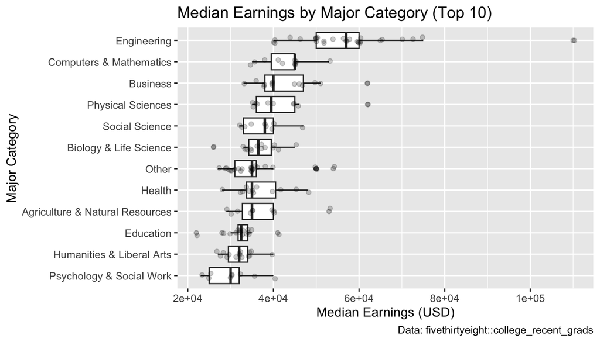

```r
grads2 %>%
  mutate(major_category = fct_lump_n(major_category, n = 10)) %>%
  ggplot(aes(x = fct_reorder(major_category, median_earn, .fun = median, na.rm = TRUE),
             y = median_earn)) +
  geom_boxplot(outlier.alpha = 0.3) +
  geom_jitter(width = 0.15, alpha = 0.2) +
  coord_flip() +
  labs(title = "Median Earnings by Major Category (Top 10)",
       x = "Major Category", y = "Median Earnings (USD)",
       caption = "Data: fivethirtyeight::college_recent_grads")
```

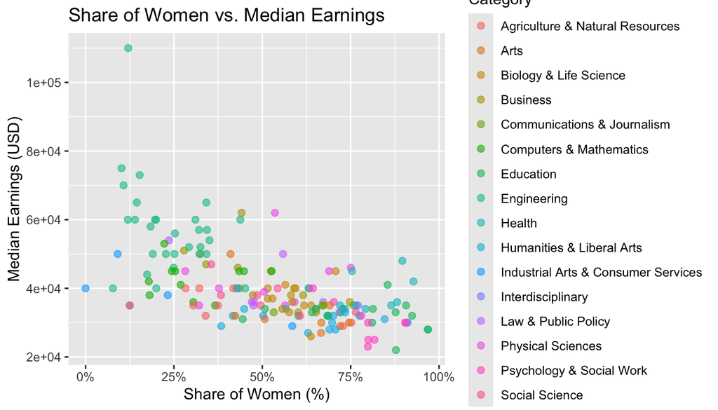

```r
# Relationship between share of women and earnings
grads2 %>%
  ggplot(aes(x = share_women_pct, y = median_earn, color = major_category)) +
  geom_point(alpha = 0.6, size = 2) +
  scale_x_continuous(labels = scales::label_percent(scale = 1)) +
  labs(title = "Share of Women vs. Median Earnings",
       x = "Share of Women (%)", y = "Median Earnings (USD)",
       color = "Category")
```

## 9. Readr

```r
# Save a processed CSV
readr::write_csv(grads2, "college_recent_grads_processed.csv")
```

### Conclusion

This vignette shows how the Tidyverse simplifies data analysis through consistent and readable syntax. Using the college_recent_grads dataset from fivethirtyeight, I explored how functions from dplyr, tidyr, and ggplot2 can transform, summarize, and visualize real-world data efficiently. Each step—from selecting and mutating variables to reshaping and plotting—showed how the Tidyverse brings a clear, logical workflow for data wrangling and exploration. This example highlights how quickly meaningful insights can be derived when powerful tools like the Tidyverse are applied to structured data.